# COMP2550/COMP4450/COMP6445 - Data Science and Applied Machine Learning Lab Tutorial

Dr. Marian-Andrei Rizoiu

13 March 2019

# Introduction

This tutorial follows-up on the quantitative methods tutorial. Here you will learn how to apply typical machine learning algorithms in order to do predictions, using `R` and the `caret` data science toolkit. At the end of this tutorial, you should have a basic functioning knowledge of how to run a plethora of ML methods, but also of how to deploy tools for auxiliary techniques such as:

- Data preparation (imputation, centering/scaling data, removing correlated predictors, reducing skewness)
- Variable selection
- Model evaluation and selection

We will be using the same `#DebateNight` dataset introduced in the quantitative methods tutorial. This tutorial assumes that you have completed the previous tutorial, meaning that you know:

- the basic functionalities and the syntax of `R`;
- how to load and install packages in `R`;
- the basic plotting functionalities in `R`;
- the structure of the `#DebateNight` dataset;
- how to load and how to perform basic analysis on `#DebateNight`.

# Pre-requisites: constructing a usable numeric dataset

Most classical machine learning approaches expect a numeric dataset in a tabular format (as described in the lecture), in which features are either real numbers or discrete factors. While more complex algorithms can handle other types of data (e.g. text), in this tutorial we concentrate on numeric datasets. In your assignment you have the liberty of exploring and using any ML algorithms and any data you may wish.

We start by loading the `caret` machine learning toolkit package (we discuss `caret` later on) together with other packages required for basic data wrangling. Note that you might need to first install `caret` and/or `dplyr` using the RStudio “Packages” tab or using the command `install.packages( c("caret", "dplyr"), dependencies = TRUE)` in the console.

```r
# load in packages
library(caret)
library(dplyr)
```

### Loading the `#DebateNight` dataset

We start with a series of operation already performed in quantitative measures tutorial. First, we load the 100,000 sample of the `#DebateNight` dataset:

```r
# load the dataset
data_df <- read.csv("sample_users_100k.csv", sep="\t", stringsAsFactors = F)
```

Next, we coerce the `botscore` variable to be numeric and we correct abnormal values:

```r
# make botscore numerical and correct invalid data
data_df$botscore <- as.numeric(data_df$botscore)
toDel <- which(data_df$botscore < 0)
data_df <- data_df[-toDel,]
toDel <- which(is.na(data_df$botscore))
data_df <- data_df[-toDel,]
```

[output not shown]

[output cut: 226 more lines]

```r
summary(data_df)
```

[output not shown]

### Construct a numerical dataset.

Let’s explore the types of features in `data_df` using the `str` command.

```r
str(data_df)
```

```
'data.frame':   88143 obs. of  29 variables:
 $ user_id             : num  7.48e+17 9.15e+07 1.84e+08 1.69e+07 3.88e+08 ...
 $ user_name           : chr  "HotRodd01" "Ozzzyyy19" "beenjamminbaker" "AndrewSmith810" ...
 $ collectionDate      : chr  "2016-09-27 02:14:27" "2016-09-27 01:24:40" "2016-09-27 01:35:00" "2016-09-27 02:36:56" ...
 $ displayName         : chr  "Hot Rodd" "Erin Osborn" "Ben Baker" "Andrew Smith" ...
 $ utcOffset           : int  -25200 -25200 NA -14400 -18000 -25200 3600 NA -14400 -14400 ...
 $ statusesCount       : int  2114 22773 34 6269 770 926 48739 1548 128 4919 ...
 $ link                : chr  "http://www.twitter.com/HotRodd01" "http://www.twitter.com/Ozzzyyy19" "http://www.twitter.com/beenjamminbaker" "http://www.twitter.com/AndrewSmith810" ...
 $ image               : chr  "https://pbs.twimg.com/profile_images/748220664411226112/nB_qhjpl_normal.jpg" "https://pbs.twimg.com/profile_images/780260203291828224/9o8NU_5-_normal.jpg" "https://pbs.twimg.com/profile_images/1112120403/Untitled_normal.png" "https://pbs.twimg.com/profile_images/430499…
 $ twitterTimeZone     : chr  "Pacific Time (US & Canada)" "Arizona" NA "Eastern Time (US & Canada)" ...
 $ summary             : chr  "A PSO for guys and girls and a dancer in NYC!! Call me http://bit.ly/2cjZv0P and http://bit.ly/2cobg76 and http"| __truncated__ "herringboy is my favorite boy. HockeyBlackhawksHockey. tulsa soccer fan. 21. NSU alum. Romans 8:31" NA "photographer. editor. journalist. al…
 $ postedTime          : chr  "2016-06-29 18:21:34" "2009-11-21 00:41:15" "2010-08-27 21:35:31" "2008-10-20 02:18:00" ...
 $ listedCount         : int  11 2 0 47 5 8 51 2 0 14 ...
 $ objectType          : chr  "person" "person" "person" "person" ...
 $ favoritesCount      : int  35 1557 0 226 1374 591 8142 628 2324 2516 ...
 $ friendsCount        : int  494 540 40 1082 891 286 1723 59 383 218 ...
 $ followersCount      : int  157 441 15 850 291 171 421 46 0 254 ...
 $ verified            : logi  FALSE FALSE FALSE TRUE FALSE FALSE ...
 $ location.displayName: chr  "New York, NY" "Oklahoma, USA" "Washington State" "Washington, DC" ...
 $ location.objectType : chr  "place" "place" "place" "place" ...
 $ botscore            : num  0.32 0.24 0.35 0.29 0.26 0.21 0.34 0.3 0.29 0.23 ...
 $ mcsize              : num  NA NA 1 1.2 NA 1 1 1 NA 1 ...
 $ influence           : num  1 1 1 1.17 1 ...
 $ influence_percentile: num  0.279 0.669 0.116 0.877 0.429 ...
 $ tweetsCount         : int  0 NA 1 5 0 1 10 2 NA 1 ...
 $ retweetsCount       : int  1 NA 0 1 1 0 7 0 NA 0 ...
 $ bias_polarity       : num  NA NA NA NA NA NA NA NA NA NA ...
 $ bias_engagement     : int  NA NA NA NA NA NA NA NA NA NA ...
 $ sum_betweenness     : int  2754648 NA NA 0 0 NA 234 NA NA NA ...
 $ psi                 : num  3.15 1.22 2.66 1.27 3.06 ...
```

- we keep all numerical features and we drop entries with `NA` values;
- we convert `verified` to numerical (True to 1 and False to 0; `NA` to 0);
- for `location.objectType`, we convert “place” to 1, `NA` to 0;
- for `mcsize` (i.e. mean cascade size, the mean size of cascades started by a given user, [see full meaning in the paper here](https://arxiv.org/pdf/1802.09808.pdf): https://arxiv.org/pdf/1802.09808.pdf): convert `NA` to 0.

```r
# Deal with missing value and category variables:
features = c(
  'listedCount', # drop na
  'favoritesCount', # drop na
  'friendsCount', # drop na
  'followersCount', # drop na
  'verified', # convert True to 1 and False to 0; na to 0
  'location.objectType', # convert "place" to 1, na to 0
  'mcsize', # convert na to 0
  'influence', # drop na
  'influence_percentile', # drop na
  'tweetsCount', # drop na
  'retweetsCount', # drop na
  'psi',
  'botscore' # drop na
)
# keep only selected features
data_df <- data_df[, features]
# clean verified
data_df$verified[is.na(data_df$verified)] <- F
data_df$verified <- data_df$verified * 1
# clean location.objectType
data_df$location.objectType[data_df$location.objectType == "place"] <- 1
data_df$location.objectType[is.na(data_df$location.objectType)] <- 0
data_df$location.objectType <- as.numeric(data_df$location.objectType)
# clean mcsize
data_df$mcsize[is.na(data_df$mcsize)] <- 0
# remove non-complete entries
toKeep <- rowSums(is.na(data_df)) == 0
data_df <- data_df[toKeep, ]
data_df$verified[1:500]
```

```
  [1] 0 0 1 0 0 0 0 0 0 0 0 0 0 0 0 0 0 0 0 0 0 0 0 0 0 0 0 0 0 0 0 0 0 0 0 0 0 0 0 0 0 0 0
 [44] 0 0 1 0 0 0 0 0 0 0 0 0 0 0 0 0 0 0 0 0 0 0 0 0 0 0 0 0 0 0 0 0 0 0 0 0 0 0 0 0 0 0 0
 [87] 0 0 0 0 0 0 0 0 0 0 0 0 0 0 0 0 0 0 0 0 0 0 0 0 0 0 0 0 0 0 0 0 0 0 0 0 0 0 0 0 0 0 0
[130] 0 0 0 0 0 0 0 0 0 0 0 0 0 0 0 0 0 0 0 0 0 0 0 0 0 0 0 0 0 0 0 0 0 0 0 0 0 0 0 0 0 1 0
[173] 0 0 0 0 0 0 0 0 0 0 0 0 0 0 0 0 0 0 0 0 0 0 0 0 0 0 0 0 0 0 0 0 0 0 0 0 0 0 0 0 0 0 0
[216] 0 0 0 0 0 0 0 0 0 0 0 0 0 0 0 0 0 0 0 1 0 0 0 0 0 0 0 0 0 0 0 0 0 0 0 0 0 0 0 0 0 0 0
[259] 0 0 0 0 0 0 0 0 0 0 0 0 0 0 0 0 0 0 0 0 0 0 0 0 0 0 0 1 0 1 0 0 0 0 0 0 0 0 0 0 0 0 0
[302] 0 0 0 0 0 0 0 0 0 0 0 0 0 0 0 0 0 0 0 0 0 0 0 0 0 0 0 0 0 0 0 0 0 0 0 0 0 0 0 0 0 0 0
[345] 0 0 0 0 0 0 0 0 0 0 0 0 0 0 0 0 0 0 0 0 0 0 0 0 0 0 0 0 0 0 0 0 0 0 0 0 0 0 0 0 0 0 0
[388] 0 0 0 0 0 0 0 0 0 0 0 0 0 0 0 0 0 0 0 0 0 0 0 0 0 0 0 0 0 0 0 0 0 0 0 0 0 0 0 0 0 0 0
[431] 0 0 0 0 0 0 0 0 0 1 0 0 0 0 0 0 0 0 0 0 0 0 0 0 0 0 0 0 0 0 0 0 0 0 0 1 0 0 0 0 0 0 0
[474] 0 0 0 0 0 0 0 0 0 0 0 0 0 0 0 0 0 0 0 0 0 0 0 0 0 0 0
```

For speeding up training and testing, in the rest of this tutorial we use a sample of 1000 rows for training, and another 1000 rows sample for testing. Note that in your assignment, for best performances, you will want to learn on as many entries as possible (ideally all 100,000).

```r
# first construct a train and a test sample, each of 1000 users
# set.seed(287)
sample2k <- sample_n(tbl = data_df, size = 2000, replace = F)
data_train <- sample2k[1:1000,]
data_test <- sample2k[1001:2000,]
```

Finally, let’s take a look at the summary of the training dataset:

```r
print(sprintf("Our sample has %d rows", nrow(data_train)))
```

```
[1] "Our sample has 1000 rows"
```

```r
summary(data_train)
```

```
  listedCount       favoritesCount    friendsCount     followersCount        verified
 Min.   :    0.00   Min.   :     0   Min.   :    0.0   Min.   :     0.0   Min.   :0.000
 1st Qu.:    1.00   1st Qu.:   195   1st Qu.:  161.8   1st Qu.:    85.8   1st Qu.:0.000
 Median :    4.00   Median :  1157   Median :  325.0   Median :   251.5   Median :0.000
 Mean   :   45.85   Mean   :  5006   Mean   :  627.3   Mean   :  2419.9   Mean   :0.011
 3rd Qu.:   14.00   3rd Qu.:  4482   3rd Qu.:  668.2   3rd Qu.:   655.2   3rd Qu.:0.000
 Max.   :22211.00   Max.   :264718   Max.   :22533.0   Max.   :971248.0   Max.   :1.000
 location.objectType     mcsize          influence      influence_percentile
 Min.   :0.000       Min.   :  0.000   Min.   : 1.000   Min.   :0.1164
 1st Qu.:0.000       1st Qu.:  0.000   1st Qu.: 1.000   1st Qu.:0.2041
 Median :1.000       Median :  0.000   Median : 1.000   Median :0.4947
 Mean   :0.659       Mean   :  0.839   Mean   : 1.254   Mean   :0.4885
 3rd Qu.:1.000       3rd Qu.:  1.000   3rd Qu.: 1.002   3rd Qu.:0.7425
 Max.   :1.000       Max.   :105.000   Max.   :91.646   Max.   :0.9998
  tweetsCount     retweetsCount         psi              botscore
 Min.   : 0.000   Min.   : 0.000   Min.   :   0.000   Min.   :0.0000
 1st Qu.: 0.000   1st Qu.: 1.000   1st Qu.:   0.769   1st Qu.:0.1600
 Median : 0.000   Median : 1.000   Median :   1.407   Median :0.2300
 Mean   : 1.787   Mean   : 2.763   Mean   :  10.108   Mean   :0.2519
 3rd Qu.: 1.000   3rd Qu.: 3.000   3rd Qu.:   2.749   3rd Qu.:0.3300
 Max.   :63.000   Max.   :99.000   Max.   :3800.000   Max.   :0.9971
```

# Caret: an `R` package for machine learning

In the rest of this tutorial, we will applying Machine Learning (ML) techniques in order to learn and predict the `botscore` class variable in `#DebateNight` as a function of all the other features in the dataset. We will perform two tasks: a **regression task** in which we aim to predict a real value (i.e. the botscore) a **classification task** in which the class variable is discrete (i.e. we predict if a particular is a bot or not). Let’s start by looking at an example.

### A simple exercise

Imagine that you want to understand the relationship between the $\psi$ measure introduced earlier and the `botness` score. In the previous tutorial you have already used statistical testing to show that $\phi$ and `botness` are related. Now we want to quantify this relationship. A good starting point would be to simply plot the data, so first, we’ll create a scatterplot:

```r
large_psi_nofollow = data_train[which(data_train$psi>12 & data_train$followersCount==0), ]
psi_aug = large_psi_nofollow[, c('psi', 'followersCount', 'friendsCount')]
psi_aug
```

| psi | followersCount | friendsCount |
| --- | --- | --- |

```r
data_train[which(data_train$psi>12 & data_train$followersCount==0), ] <- 1
data_train[which(data_train$psi>12), ][, c('psi', 'followersCount', 'friendsCount')]
```

|  | psi | followersCount | friendsCount |
| --- | --- | --- | --- |
| 98606 | 15.51379 | 25 | 388 |
| 58539 | 39.80100 | 2 | 80 |
| 81995 | 16.27907 | 3 | 49 |
| 44326 | 14.87236 | 9 | 134 |
| 11771 | 33.10431 | 16 | 530 |
| 29343 | 43.54602 | 34 | 1481 |
| 19157 | 13.62126 | 3 | 41 |
| 1803 | 132.33831 | 2 | 266 |
| 59681 | 22.55489 | 5 | 113 |
| 25270 | 50.52474 | 20 | 1011 |

[output cut: 9 more lines]

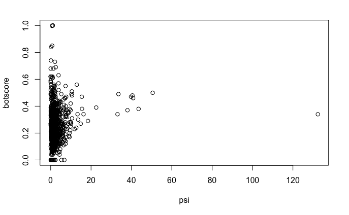

```r
plot(formula = botscore ~ psi, data = data_train)
```

It appears that there are limitations to how much we can learn about the relation of $\psi$ and the botscore from simple descriptive analysis and plotting. Let us turn to machine learning techniques.

```r
# datapoints with high psi value
psi_comp = c('friendsCount', 'followersCount', 'psi')
large_psi = data_train[which(data_train$psi > 12), ]
large_psi[, psi_comp]
```

[output not shown]

[output cut: 12 more lines]

### A quick introduction to caret

`R` has a wide number of packages for ML, which is great, but also quite frustrating since each package was designed independently and has very different syntax, inputs and outputs. This means that if you want to do machine learning in `R`, you have to learn a large number of separate methods.

`Caret` stands for **C**lassification **A**nd **Re**gression **T**raining and it solves the aforementioned problem by streamlining the learning process. `Caret` provides tools for almost every part of the model building process, and moreover, provides a common interface to these different machine learning methods. For example, `caret` provides a simple, common interface to almost every machine learning algorithm in R. When using caret, different learning methods like linear regression, neural networks, and support vector machines, all share a common syntax (the syntax is basically identical, except for a few minor changes). An extensive vignette for caret can be found here: https://topepo.github.io/caret/index.html

### A simple view of caret: the default `train` function

Imagine you want to learn from data the relationship between $\psi$ and botscore. In mathematical terms, this means identifying a function, $f(\psi)$, that describes the relationship between $\psi$ and botscore. Initially, we make an additional assumption that this relationship is linear; we’ll assume that that it can be described by a straight line of the form $f(\psi) = \beta_0 + \beta_1 \psi$. Therefore, we will use a linear regressions to build our machine learning model.

To implement your machine learning model of choice using caret, your main tool is the `train` function. The options for the method (model) are many and are listed here: https://topepo.github.io/caret/available-models.html. Here is the syntax for learning our linear regression model:

```r
# can we train a linear model to this?
fitControl <- trainControl(
  # Repeated 5–fold CV
  method = "repeatedcv",
  number = 10,
  # repeated 10 times
  repeats = 10,
  returnResamp = "all")
model_lm_psi <- train(botscore ~ psi, data = data_train,
                      method = "lm", trControl = fitControl)
```

That’s it. The syntax for building a linear regression is extremely simple with caret. Now, let’s look more closely at the syntax and how it works.

When training a model using `train()`, you only need to tell it a few things:

– The dataset you are working with  
– The target variable you are trying to predict (e.g., the `botscore` variable)  
– The input variable (e.g., the `psi` variable)  
– The machine learning method you want to use (in this case “linear regression”)

**Formula notation.** In caret’s syntax, you identify the target variable and input variables using the “formula notation.” The basic syntax for formula notation is y ~ x, where y is your target variable, and x is your predictor.

Effectively, y ~ x tells caret “I want to predict y on the basis of a single input, x.”"

Now, with this knowledge about caret’s formula syntax, let’s reexamine the above code. Because we want to predict `botscore` on the basis of $\psi$, we use the formula `botscore ~ psi`.

**The data = parameter.** The `train()` function also has a `data =` parameter, which tells the `train()` function what dataset we’re using to build the model. `data = data_train` tells `caret` that the data and the relevant variables can be found in the training dataset that we constructed earlier.

**The method = parameter.** This parameter indicates what machine learning method we want to use to predict `botscore`. In this case, we are building a linear regression model, so we are using the argument “lm”. Later, we will use “random forests” and you will have all the liberty of trying as many models as you with in the assignment.

### Visualizing the linear model

So far, we have only trained the linear model, now we will visualize it and use it for prediction. We can obtain a number of information about our trained model (such as re-sampling strategy, performance measures on the training set) by simply executing:

```r
model_lm_psi
```

```
Linear Regression

1000 samples
   1 predictor

No pre-processing
Resampling: Cross-Validated (10 fold, repeated 10 times)
Summary of sample sizes: 900, 900, 900, 900, 901, 901, ...
Resampling results:

  RMSE       Rsquared    MAE
  0.1332658  0.03011499  0.09973284

Tuning parameter 'intercept' was held constant at a value of TRUE
```

Furthermore, in the two dimensional space of $\psi$ and `botscore`, a linear model is a straight line. Let’s see how that looks like:

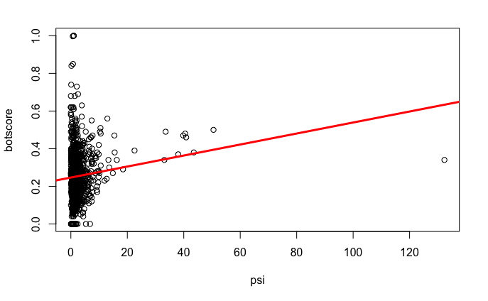

```r
plot(formula = botscore ~ psi, data = data_train)
# retrieve coefficients for the slope and for psi
coef.icept <- coef(model_lm_psi$finalModel)[1]
coef.slope <- coef(model_lm_psi$finalModel)["psi"]
abline(a = coef.icept, b = coef.slope, col = "red", lwd = "3")
```

Is this good? Looks alright for some of the points with high values of $\psi$ but unclear for the rest.

```r
# predict the outcome on a test set
model_lm_psi_pred <- predict(model_lm_psi, data_test)
```

How well does it do?

```r
head(data.frame(predicted = model_lm_psi_pred,
                observed = data_test$botscore, row.names = NULL), n=10)
```

|  | predicted | observed |
| --- | --- | --- |
| 1 | 0.2504602 | 0.36 |
| 2 | 0.2500741 | 0.17 |
| 3 | 0.2468604 | 0.28 |
| 4 | 0.2506532 | 0.22 |
| 5 | 0.2487639 | 0.04 |
| 6 | 0.2503652 | 0.10 |
| 7 | 0.2468301 | 0.30 |
| 8 | 0.2490745 | 0.20 |
| 9 | 0.2510934 | 0.38 |
| 10 | 0.2510596 | 0.13 |

Is this good? Rather than looking at raw predictions, we can compute performance measures using the `postResample` function:

```r
metrics <- data.frame(matrix(data = NA, nrow = 3, ncol = 0))
metrics <- cbind(metrics, LM_psi = postResample(pred = model_lm_psi_pred,
                                                obs = data_test$botscore) )
metrics
```

[output not shown]

This outputs three performance measures:

- [RMSE (Root Mean Square Error)](https://en.wikipedia.org/wiki/Root-mean-square_deviation) represents the sample standard deviation of the differences between predicted values and observed values. Lower is better;
- [Rsquared $R^2$](https://en.wikipedia.org/wiki/Coefficient_of_determination) is the coefficient of determination – i.e. the proportion of the variance in the dependent variable that is predictable from the independent variable(s). Higher is better;
- [MAE (Mean Absolute Error)](https://en.wikipedia.org/wiki/Mean_absolute_error) is a measure of difference between two paired continuous variables. Lower is better.

Which one to use? They all have their pluses and minuses, that is why we report them all here. The results seem not too bad, but they are averaged results, highly influenced by the outliers. Let’s compute Absolute Relative Error (ARE) for each data point as:

$ARE(u) = \frac{\overline{botscore(u)} - botscore(u)}{botscore(u)}$

where $\overline{botscore(u)}$ is the predicted value for `botscore`. The Mean ARE (MARE) is indicative of how well do we predict overall.

```r
ARE_df <- data.frame(matrix(data = NA, nrow = nrow(data_test), ncol = 0))
ARE_df <- cbind(ARE_df,
                LM_psi = abs(model_lm_psi_pred - data_test$botscore) / data_test$botscore)
ARE_df <- do.call(data.frame, lapply(ARE_df, function(x) replace(x, is.infinite(x), NA)))
metrics <- rbind(metrics, MARE = apply(X = ARE_df, MARGIN = 2, FUN = mean, na.rm = T))

print(metrics, digits = 2)
```

[output not shown]

```r
boxplot(x = ARE_df, outline = F, names = names(ARE_df),
        main = "Prediction ARE", ylab = "ARE")
points(apply(X = ARE_df, MARGIN = 2, FUN = mean, na.rm = T),
       pch = 23, col = "red", bg = "red", cex = 2)
text(x = 1:ncol(ARE_df), y = apply(X = ARE_df, MARGIN = 2, FUN = mean, na.rm = T) - 0.06,
     labels = sprintf("%.3f", apply(X = ARE_df, MARGIN = 2, FUN = mean, na.rm = T)) )
text(x = 1:ncol(ARE_df), y = apply(X = ARE_df, MARGIN = 2, FUN = median, na.rm = T) - 0.03,
     labels = sprintf("%.3f", apply(X = ARE_df, MARGIN = 2, FUN = median, na.rm = T)) )
```

[output not shown]

### Simple feature engineering – percentiles of $\psi$

From the scatterplot shown earlier, the $\psi$ measure appears to have a skewed distribution and the relation with the `botscore` does not seem linear. We perform a simple feature engineering, by computing the percentiles of $\psi$ and using that to predict `botscore` instead of the real value:

```r
myecdf <- ecdf(sample2k$psi)
data_train$psi_percentile <- myecdf(data_train$psi)
data_test$psi_percentile <- myecdf(data_test$psi)
```

Let’s plot the new scatterplot:

```r
plot(formula = botscore ~ psi_percentile, data = data_train)
```

[output not shown]

```r
model_lm_1 <- train(botscore ~ psi_percentile, data = data_train,
                    method = "lm", trControl = fitControl)
# get 2D line
coef.icept <- coef(model_lm_1$finalModel)[1]
coef.slope <- coef(model_lm_1$finalModel)["psi_percentile"]

# and plot it
plot(formula = botscore ~ psi_percentile, data = data_train)
abline(a = coef.icept, b = coef.slope, col = "red")
```

and test on the unseen data:

```r
# predict the outcome on a test set
model_lm_pred_1 <- predict(model_lm_1, data_test)

ARE_df <- cbind(ARE_df,
                LM_psi_perc = abs(model_lm_pred_1 - data_test$botscore) / data_test$botscore)
ARE_df <- do.call(data.frame, lapply(ARE_df, function(x) replace(x, is.infinite(x), NA)))

# compare predicted outcome and true outcome
metrics <- cbind(metrics,
                 LM_psi_perc = c(postResample(pred = model_lm_pred_1, obs = data_test$botscore),
                                 mean(ARE_df$LM_psi_perc, na.rm = T) ) )
print(metrics, digits = 2)
```

and plot the boxplot of the ARE performance:

```r
boxplot(x = ARE_df, outline = F, names = names(ARE_df),
        main = "Prediction ARE", ylab = "ARE")
points(apply(X = ARE_df, MARGIN = 2, FUN = mean, na.rm = T),
       pch = 23, col = "red", bg = "red", cex = 2)
text(x = 1:ncol(ARE_df), y = apply(X = ARE_df, MARGIN = 2, FUN = mean, na.rm = T) - 0.06,
     labels = sprintf("%.3f", apply(X = ARE_df, MARGIN = 2, FUN = mean, na.rm = T)) )
text(x = 1:ncol(ARE_df), y = apply(X = ARE_df, MARGIN = 2, FUN = median, na.rm = T) - 0.03,
     labels = sprintf("%.3f", apply(X = ARE_df, MARGIN = 2, FUN = median, na.rm = T)) )
```

```r
model_lm_2 <- train(botscore ~ ., data = data_train,
                    method = "lm", trControl = fitControl)

# predict the outcome on a test set
model_lm_pred_2 <- predict(model_lm_2, data_test)

## compute error metrics
ARE_df <- cbind(ARE_df,
                LM_all = abs(model_lm_pred_2 - data_test$botscore) / data_test$botscore)
ARE_df <- do.call(data.frame, lapply(ARE_df, function(x) replace(x, is.infinite(x), NA)))
# compare predicted outcome and true outcome
metrics <- cbind(metrics,
                 LM_psi_perc = c(postResample(pred = model_lm_pred_2, obs = data_test$botscore),
                                 mean(ARE_df$LM_all, na.rm = T) ) )
boxplot(x = ARE_df, outline = F, names = names(ARE_df),
        main = "Prediction ARE", ylab = "ARE")
points(apply(X = ARE_df, MARGIN = 2, FUN = mean, na.rm = T),
       pch = 23, col = "red", bg = "red", cex = 2)
text(x = 1:ncol(ARE_df), y = apply(X = ARE_df, MARGIN = 2, FUN = mean, na.rm = T) - 0.06,
     labels = sprintf("%.3f", apply(X = ARE_df, MARGIN = 2, FUN = mean, na.rm = T)) )
text(x = 1:ncol(ARE_df), y = apply(X = ARE_df, MARGIN = 2, FUN = median, na.rm = T) - 0.03,
     labels = sprintf("%.3f", apply(X = ARE_df, MARGIN = 2, FUN = median, na.rm = T)) )
```

```r
old <- par(mar = c(5, 9, 4, 2))
barplot(height = sort(coef(model_lm_2$finalModel), decreasing = T),
        horiz = T, las = 1, col = "red", main = "Feature importance")
par(old)
```

# Dataset pre-processing (`preProcess`)

As discussed in the lecture, data pre-processing can have a high impact on prediction performances. There are a number of pre-processing steps that are easily implemented by `caret`. Several stand-alone functions from `caret` target specific issues that might arise when setting up the model. These include

- `dummyVars`: creating dummy variables from categorical variables with multiple categories
- `nearZeroVar`: identifying zero- and near zero-variance predictors (these may cause issues when sub-sampling)
- `findCorrelation`: identifying correlated predictors
- `findLinearCombos`: identify linear dependencies between predictors

In addition to these individual functions, there also exists the **`preProcess`** function which can be used to perform more common tasks such as centering and scaling, imputation and transformation. `preProcess` takes in a data frame to be processed and a method which can be any of “BoxCox”, “YeoJohnson”, “expoTrans”, “center”, “scale”, “range”, “knnImpute”, “bagImpute”, “medianImpute”, “pca”, “ica”, “spatialSign”, “corr”, “zv”, “nzv”, and “conditionalX”.

On the training set data we will center, scale and perform a YeoJohnson transformation, identify and remove variables with near zero variance and perform pca in one command:

```r
data_train_preproc <- preProcess(select(data_train, - botscore),
                                 method = c("center", "scale", "YeoJohnson", "nzv", "pca"))
data_train_preproc
```

Identify which variables were ignored, centered, scaled, etc

```r
data_train_preproc$method
```

and identify the principal components:

```r
data_train_preproc$rotation
```

We obtain pre-processed versions of the training and testing datasets by calling the `predict()` function, using the output of `preProcess()` as a model:

```r
# construct pre-processed training and testing datasets
train_df <- predict(data_train_preproc, data_train)
test_df <- predict(data_train_preproc, data_test)
head(train_df)
```

Let us see how this affects a linear model training and prediction:

```r
model_lm_3 <- train(botscore ~ ., data = train_df,
                    method = "lm", trControl = fitControl)
model_lm_pred_3 <- predict(model_lm_3, test_df)

ARE_df <- cbind(ARE_df,
                LM_preproc = abs(model_lm_pred_3 - data_test$botscore) / data_test$botscore)
ARE_df <- do.call(data.frame, lapply(ARE_df, function(x) replace(x, is.infinite(x), NA)))

boxplot(x = ARE_df, outline = F, names = names(ARE_df),
        main = "Prediction ARE", ylab = "ARE")
points(apply(X = ARE_df, MARGIN = 2, FUN = mean, na.rm = T),
       pch = 23, col = "red", bg = "red", cex = 2)
text(x = 1:ncol(ARE_df), y = apply(X = ARE_df, MARGIN = 2, FUN = mean, na.rm = T) - 0.06,
     labels = sprintf("%.3f", apply(X = ARE_df, MARGIN = 2, FUN = mean, na.rm = T)) )
text(x = 1:ncol(ARE_df), y = apply(X = ARE_df, MARGIN = 2, FUN = median, na.rm = T) - 0.03,
     labels = sprintf("%.3f", apply(X = ARE_df, MARGIN = 2, FUN = median, na.rm = T)) )
```

Compute performance metrics:

```r
# compare predicted outcome and true outcome
metrics <- cbind(metrics,
                 LM_preproc = c(postResample(pred = model_lm_pred_3, obs = test_df$botscore),
                                mean(ARE_df$LM_preproc, na.rm = T) ) )
```

and plot them comparatively for each approach:

```r
par(mfrow=c(1,4))
for (i in 1:4) {
  barplot(height = unlist(metrics[i,]), names.arg = names(metrics),
          main = rownames(metrics)[i], col = cm.colors(4)[1:4])
}
```

# Removing the hypothesis of linear dependency

Up to here, we have been gradually improving the prediction performances. However, one assumption has not changed: we constantly assumed a linear relation between the descriptive features and the `botscore`. But how realistic is such an assumption? Let us revisit the relation between $\psi$ and `botscore` and further analyze the distribution of $\psi$:

```r
par(mfrow=c(1,3))

# scatterplot of psi and botness
plot(formula = botscore ~ psi, data = data_train)
# histogram of psi
hist(data_train$psi, breaks = 1000, main = "Histogram of Psi", xlab = "Psi")
# log-log plot of CCDF of psi
myecdf <- ecdf(x = data_df$psi)
myx <- seq(from = range(data_df$psi)[1], to = range(data_df$psi)[2], length.out = 1000)
plot(x = myx, y = 1 - myecdf(myx),
     type = "l", lwd = 3, col = "blue", log = "xy",
     main = "(log-log) Empirical CCDF of Psi", xlab = "Psi", ylab = "Empirical CCDF")
```

[output not shown]

The main effect of a long-tail distributed feature is that the relation between itself and the response variable (here `botness`) is unlikely to be linear. Therefore, linear models (such as the linear regression) appear badly suited to predict `botness`. Luckily, there exist non-linear regressors. Next we use such a non-linear learning algorithm, **random forests**:

```r
model_rf <- train(botscore ~ ., data = data_train,
                  method = "ranger", trControl = fitControl)
# predict the outcome on a test set
model_rf_pred <- predict(model_rf, data_test)

ARE_df <- cbind(ARE_df, RF = abs(model_rf_pred - data_test$botscore) / data_test$botscore)
ARE_df <- do.call(data.frame, lapply(ARE_df, function(x) replace(x, is.infinite(x), NA)))
# compare predicted outcome and true outcome
metrics <- cbind(metrics,
                 RF = c(postResample(pred = model_rf_pred, obs = test_df$botscore),
                        mean(ARE_df$RF, na.rm = T) ) )
```

```r
boxplot(x = ARE_df, outline = F, names = names(ARE_df),
        main = "Prediction ARE", ylab = "ARE")
points(apply(X = ARE_df, MARGIN = 2, FUN = mean, na.rm = T),
pch = 23, col = "red", bg = "red", cex = 2)
text(x = 1:ncol(ARE_df), y = apply(X = ARE_df, MARGIN = 2, FUN = mean, na.rm = T) - 0.06,
     labels = sprintf("%.3f", apply(X = ARE_df, MARGIN = 2, FUN = mean, na.rm = T)) )
text(x = 1:ncol(ARE_df), y = apply(X = ARE_df, MARGIN = 2, FUN = median, na.rm = T) - 0.03,
     labels = sprintf("%.3f", apply(X = ARE_df, MARGIN = 2, FUN = median, na.rm = T)) )
```

and comparatively for each measure:

```r
par(mfrow=c(1,4))
for (i in 1:4) {
  barplot(height = unlist(metrics[i,]), names.arg = names(metrics),
          main = rownames(metrics)[i], col = cm.colors(ncol(metrics))[1:ncol(metrics)])
}
```

# Classification

When the target class variable is discrete instead of a real number, the prediction exercise is called **classification** (instead of **regression**). There are dedicated algorithms for classification, and this exercise has its own hurdles (some of which we will find in the rest of this tutorial).

One simple interpretation for `botness` is the “probability of a user being a bot” (`botness`$\in [0,1]$). We can construct a binary variable (`is_bot`) by binarizing the `botness` variable: when `botness` $> 0.5$, we consider the user to be a bot, when `botness`$\le 0.5$ the user is a human.

```r
# binarize the botscore
sample2k$is_bot <- F
sample2k$is_bot[sample2k$botscore > 0.5] <- T
sample2k$is_bot <- factor(sample2k$is_bot)
sample2k$botscore <- NULL

summary(sample2k)
```

Next, we will apply the **logistic regression** classification algorithm to detect bots. There are many, many, many other algorithms out there for you to try out in your assignment. First, we reconstruct the training and testing dataset to contain the `is_bot` features:

```r
data_train <- sample2k[1:1000,]
data_test <- sample2k[1001:2000,]

summary(data_train)
```

```r
# let's apply a logistic regression with the same sampling setup as the regression task
model_logistic <- train(is_bot ~ ., data = data_train,
                        method = "glm", family="binomial", trControl = fitControl)
model_logistic
```

and we can test it on the testing set:

```r
model_logistic_pred <- predict(model_logistic, data_test, type="raw")
postResample(pred = model_logistic_pred, obs = data_test$is_bot)
```

```r
pred_obs <- data.frame(predicted = model_logistic_pred, observed = data_test$is_bot)
confusionMatrix(data = model_logistic_pred, reference = data_test$is_bot,
                dnn = c("Predicted", "Observed"), positive = "TRUE", mode = "everything")
```

In `caret` we can easily compute Precision, Recall and F-Measure (outside of the `confusionMatrix()` function) using pre-existing functions. Note that we need to specify the “relevant” class (class of interest or “positive” class in the `confusionMatrix()` function):

```r
measures <- c(precision = precision(data = model_logistic_pred,
                                    reference = data_test$is_bot,
                                    relevant = "TRUE"),
              recall = recall(data = model_logistic_pred,
                              reference = data_test$is_bot,
                              relevant = "TRUE"),
              fmeasure = F_meas(data = model_logistic_pred,
                                reference = data_test$is_bot,
                                relevant = "TRUE") )
print(measures, digits = 2)
```

# The way ahead: your assignment

Here are a number of things that you can try in your assignment (for both classification and regression):

- **stratified sampling** – make sure the folds on which you learn contain both classes in the same percentage as the entire dataset;
- **oversampling, undersampling** – are both strategies to re-balance the dataset and improve prediction performance of the minority class;
- **try out other classifiers** – you can explore more complex and/or more powerful classifiers. One technique you might want to look into is bagging (ensemble methods), which take a set of weak classifiers and output one strong classifier through a voting system;
- **feature preprocessing** – in this tutorial we only scratched the surface of all the ways you can pre-process your dataset to improve prediction performance. Remember that 75% of the time invested in ML prediction is in understanding and processing your features. For example, taking percentiles of a long-tailed feature is only one way you can correct the skewness, taking the `log` is another. And we haven’t yet looked at the other features. How are they distributed? Does that impact prediction?
- **more data** – at the beginning to this tutorial, we constructed a numerical dataset and we have thrown away half of the features because they were not numeric. But maybe there is information in there crucial to detecting bots. How do we extract that?
- **external data** – you can use anything out there to improve the training of your classifier/regressor. Twitting patterns and the graph of other users might be indicative. *However, bear in mind that this information will not be available in the test set*!